# Posts – David Chudzicki

David Chudzicki

- about
- posts

## Cov

February 20, 2014

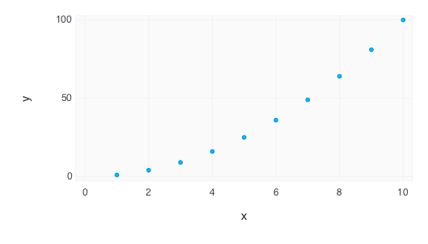

```julia
using Gadfly
Gadfly.prepare_display()
Gadfly.set_default_plot_size(14cm, 8cm)
set_default_plot_format(:png)

# Binding categorial data to the color aesthetic
plot(x=[1:10], y=[1:10].^2, Geom.point)
```

## First Post

February 16, 2014

### Simulated Knitting ([post](http://blog.davidchudzicki.com/2011/11/simulated-knitting.html))

[figure not shown]

I created a `KnittedGraph` class (subclassing of Python's `igraph` graph class) with methods corresponding to common operations performed while knitting:

```python
g = KnittedGraph()
g.AddStitches(n)
g.ConnectToZero() # join with the first stitch for a circular shape
g.NewRow() # start a new row of stitches
g.Increase() # two stitches in new row connect to one stitch in old
#(etc.)
```

I then embed the graphs in 3D space. Here's a hat I made this way:

[figure not shown]

### 2D Embeddings from Unsupervised Random Forests ([1](http://blog.davidchudzicki.com/2012/08/random-forests-for-visualizing-data.html), [2](http://blog.davidchudzicki.com/2012/08/visualize-random-forest-that-classifies.html))

[figure not shown]

There are all sorts of ways to embed high-dimensional data in low dimensions for visualization. Here's one:

1. Given some set of high dimensional examples, build a random forest to distinguish examples from non-examples.
2. Assign similarities to pairs of examples based on how often they are in leaf nodes together.
3. Map examples to 2D in such a way that similarity decreases decreases with Euclidean 2D distance (I used [multidimensional scaling](https://en.wikipedia.org/wiki/Multidimensional_scaling) for this).

Here's the result of doing this on a set of diamond shapes I constructed. I like how it turned out:

[figure not shown]

### A Bayesian Model for a Function Increasing by Chi-Squared Jumps (in Stan) ([post](http://blog.davidchudzicki.com/2013/10/a-bayesian-model-for-function.html))

[figure not shown]

In [this paper](http://www.stat.columbia.edu/%7Egelman/research/published/deep.pdf), Andrew Gelman mentions a neat example where there's a big problem with a naive approach to putting a Bayesian prior on functions that are constrained to be increasing. So I thought about what sort of prior would make sense for such functions, and fit the models in Stan.

I enjoyed [Andrew's description of my attempt](http://andrewgelman.com/2013/11/22/bayesian-model-increasing-function-stan/): *"... it has a charming DIY flavor that might make you feel that you too can patch together a model in Stan to do what you need."*

[figure not shown]

### Lissijous Curves [JSFiddle](http://jsfiddle.net/dchudz/yYZZy/embedded/result/))

Some JavaScript I wrote (using d3) to mimick what an oscilloscope I saw at the Exploratorium was doing:

[figure not shown]

### Visualization of the Weirstrass Elliptic Function as a Sum of Terms

[figure not shown]

http://blogs.ams.org/visualinsight/2014/01/15/weierstrass-elliptic-function/